# Data Preprocessing and cleaning

LIBRERIE

```r
library(dplyr)
library(sf)
library(osmdata)
library(ggplot2)
library(ggmap)
library(tidyr)
```

DATA IMPORT

```r
rm(list=ls()) # remove all variables

# dati del 2023
dati2023 <- read.csv("dati/Dati_sensori_aria_2023.csv")
dati2018 <- read.csv("dati/Dati_sensori_aria_dal_2018.csv")

# import station dataset
stationData1 <- read.csv("dati/Stazioni_qualit__dell_aria_2024.csv")
stationData2 <- read.csv("dati/Stazioni_qualit__dell_aria_NRT_2024.csv")
```

Concatenazione dei dataset delle rilevazioni

```r
# I due dataset han formati diversi per la data !!!!!!!!

# convert time in a 24h format
dati2018$Data  <- strptime(dati2018$Data, format = "%m/%d/%Y %I:%M:%S %p")

# convert time in a 24h format
dati2023$Data  <- strptime(dati2023$Data, format = "%d/%m/%Y %I:%M:%S %p")

#tengo solo i dati del 2023
dati23 <- subset(dati2018, format(Data, "%Y") == "2023")
dati2023 <- subset(dati2023, format(Data, "%Y") == "2023")

# concateno i due dataset
airData <- rbind(dati2023, dati23)
# check on the year
unique(format(airData$Data, "%Y"))
```

```
[1] "2023"
```

Concatenazione dei dataset delle stazioni

```r
stationData2$Quota <- as.character(stationData2$Quota)
stationData <- bind_rows(stationData1, stationData2)

rm(list=c("stationData1", "stationData2","dati2018", "dati23","dati2023"))
```

NULL INSTANCES

```r
# count null instances
nrow(airData[airData$Valore == -9999.0,])
```

```
[1] 73174
```

```r
# save the instance with errors to study them
#errorSensor <- airData[airData$Valore == -9999.0,]

# remove null instances
airData <- airData[airData$Valore != -9999.0,]

airData <- subset(airData, !is.na(Data))
```

DUPLICATE INSTANCES

```r
# check for duplicate instances
nrow(distinct(airData)) == nrow(airData)
```

```
[1] FALSE
```

```r
length(unique(stationData$IdSensore)) == nrow((stationData))
```

```
[1] FALSE
```

```r
# rimuove misurazioni doppie
airData <- airData %>% distinct()

# rimuovi duplicati sensori
stationData <- stationData %>% distinct(IdSensore, .keep_all = TRUE)
```

OPEN ATTRIBUTE

```r
# create new attribute for the station
stationData$Open <- ifelse((stationData$DataStop == "" | is.na(stationData$DataStop)), "YES", "NO")
```

LOMBARDIA MAP

```r
# download Lombardia map
lombardiaMap <- get_stadiamap((getbb("Lombardia")), maptype = "alidade_smooth" )
```

```
ℹ © Stadia Maps © Stamen Design © OpenMapTiles © OpenStreetMap contributors.
ℹ 81 tiles needed, this may take a while (try a smaller zoom?)
```

PLOT DETECTION STATION

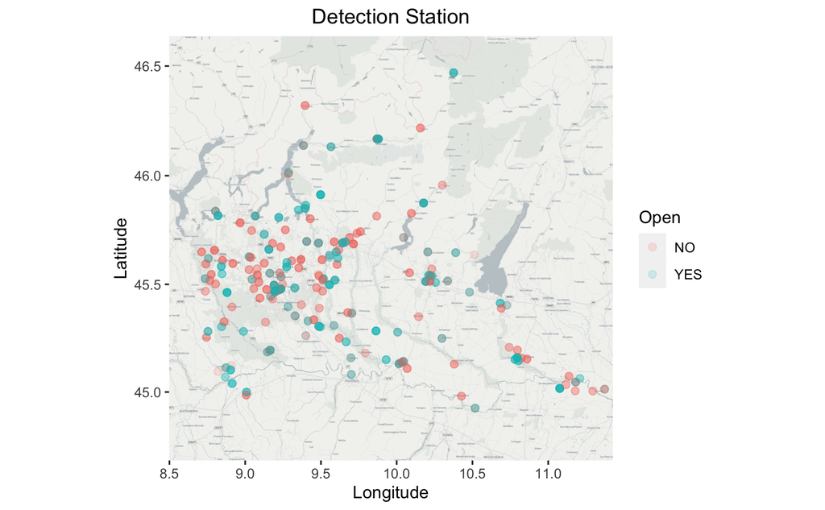

```r
# plot the detection station
plot <- ggmap(lombardiaMap) + geom_point(data = stationData,
                     aes(x = lng, y = lat, color = Open), size = 2, alpha = 0.15) +
                     ggtitle("Detection Station") +
                     labs(x = "Longitude", y = "Latitude") +
                     theme(plot.title = element_text(hjust = 0.5))
plot
```

PLOT DETECTION STATION

```r
# Read the GeoJSON Shapefile
lombardia_provinces <- st_read("dati/lombardy_.geojson")
plot <- ggplot() +
  geom_sf(data = lombardia_provinces, fill = "lightblue", color = "black") +
  # Add points from stationData
  geom_point(data = stationData, aes(x = lng, y = lat), color = "red", size = 2) +
  labs(x = "Longitude", y = "Latitude") +
  theme_minimal()
ggsave(plot, file="detectionStation.pdf", width = 11, height = 8.5)
```

DATASET MERGE

```r
fullData <- merge(airData, stationData, by = "IdSensore")

# save the lost instances
# lostInstances <- anti_join(airData, fullData, by = "IdSensore")

rm(airData)
```

PLOT MEASURED SUBSTANCE BY PROVINCE

```r
# generate a scatterplot showing which types of substances are measured in which
plot <- ggplot(fullData, aes(x = Provincia, y = NomeTipoSensore)) +
                      geom_point() +
                      labs(x = "Zone", y ="Measured Substance",
                      title = "Measured Substance in different zones")
ggsave(plot, file="sostanzeProvince.pdf", width = 11, height = 8.5)
```

PLOT INSTANCES NUMBER

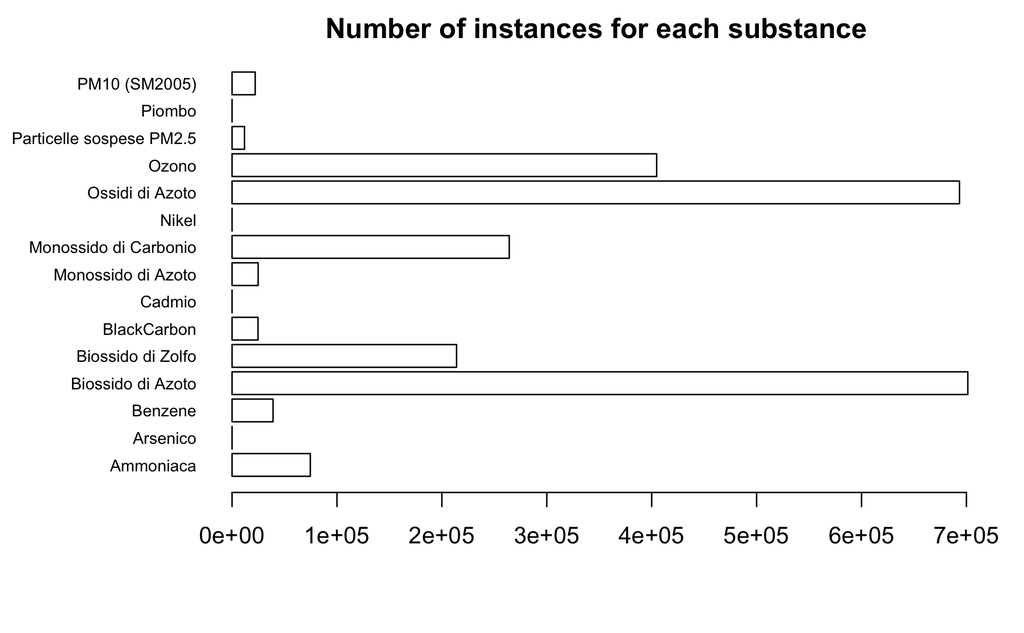

```r
# find number of instances for each substance
instanceNumber <- as.data.frame(table(fullData$NomeTipoSensore))

par(mar = c(5, 8, 2, 2))  # Adjust the margins (bottom, left, top, right)

custom_values <- instanceNumber$Freq
custom_labels <- instanceNumber$Var1[which(instanceNumber$Freq %in% custom_values)]

barplot(instanceNumber$Freq, names.arg = custom_labels, horiz = TRUE, las = 1, col = "transparent", main = "Number of instances for each substance", cex.names = 0.7)
```

```r
rm(instanceNumber)
```

PROVINCE COORDINATES

```r
# Create a data frame with province, latitude, and longitude
province <- data.frame(
  Provincia = c("BS", "BG", "CO", "CR", "LC", "LO", "MN", "MI", "MB", "PV", "SO", "VA"),
  lat = c(45.5397733, 45.6947359, 45.8119642, 45.1334974, 45.8529825, 45.3128778, 45.1603653, 45.4636707, 45.5840057, 45.1858767, 46.1712597, 45.8176046),
  lng = c(10.2229390, 9.6687071, 9.0854556, 10.0261350, 9.3900705, 9.4978501, 10.7976976, 9.1881263, 9.2730143, 9.1566316, 9.8693336, 8.8263844)
)


#https://www.dossier.net/utilities/coordinate-geografiche/provincia-monza-brianza.htm
```

BRESCIA

```r
BS <- fullData[fullData$Provincia == "BS", ]
```

```r
# Extract the month from the 'Data' column
BS <- BS %>%
  mutate(Month = format(Data, "%Y-%m"))

# Group by 'NomeTipoSensore' and 'Month', then calculate the average
BS_average_by_month <- BS %>%
  group_by(NomeTipoSensore, Month) %>%
  summarise(Average_Value = mean(Valore))
```

CORRELATION MATRIX

```r
# Load the tidyverse package
library(tidyverse)

BS_average_by_month$Month <- as.Date(paste(BS_average_by_month$Month, "-01", sep=""), format="%Y-%m-%d")

# Assuming your data is in a data frame named BS_average_by_month
# Convert Month to Date type
BS_average_by_month$Month <- as.Date(BS_average_by_month$Month)

# Reshape the data into a wide format
wide_data <- BS_average_by_month %>%
  pivot_wider(names_from = NomeTipoSensore, values_from = Average_Value)

# Calculate the correlation matrix
correlation_matrix <- cor(wide_data[, -1])  # Exclude the Month column for correlation calculation

correlation_matrix_truncated <- round(correlation_matrix, 3)

# Save correlation matrix to a text file
write.table(correlation_matrix_truncated, "correlation_matrix.txt", sep="\t", row.names=TRUE, col.names=TRUE)
```

```r
# Plot the data
plot <- ggplot(BS_average_by_month, aes(x = as.numeric(substring(Month, 6, 7)), y = Average_Value, color = NomeTipoSensore)) +
  geom_line() +
  geom_point() +
  scale_x_continuous(breaks = 1:12, labels = c("Jan", "Feb", "Mar", "Apr", "May", "Jun", "Jul", "Aug", "Sep", "Oct", "Nov", "Dec")) +
  labs(#title = "Average Values by Month",
       x = "Month",
       y = "Average Value") +
  theme_minimal() + coord_cartesian(ylim = c(0,110))

ggsave(plot, file="BSTrend.pdf", width = 8, height = 5)
```

BERGAMO

```r
BG <- fullData[fullData$Provincia == "BG", ]
```

```r
# Extract the month from the 'Data' column
BG <- BG %>%
  mutate(Month = format(Data, "%Y-%m"))

# Group by 'NomeTipoSensore' and 'Month', then calculate the average
BG_average_by_month <- BG %>%
  group_by(NomeTipoSensore, Month) %>%
  summarise(Average_Value = mean(Valore))
```

CORRELATION MATRIX

```r
# Load the tidyverse package
library(tidyverse)

BG_average_by_month$Month <- as.Date(paste(BG_average_by_month$Month, "-01", sep=""), format="%Y-%m-%d")

# Assuming your data is in a data frame named BS_average_by_month
# Convert Month to Date type
BG_average_by_month$Month <- as.Date(BG_average_by_month$Month)

# Reshape the data into a wide format
wide_data <- BG_average_by_month %>%
  pivot_wider(names_from = NomeTipoSensore, values_from = Average_Value)

# Calculate the correlation matrix
correlation_matrix <- cor(wide_data[, -1])  # Exclude the Month column for correlation calculation

correlation_matrix_truncated <- round(correlation_matrix, 3)

# Save correlation matrix to a text file
write.table(correlation_matrix_truncated, "correlation_matrix.txt", sep="\t", row.names=TRUE, col.names=TRUE)
```

```r
# Plot the data
plot <- ggplot(BG_average_by_month, aes(x = as.numeric(substring(Month, 6, 7)), y = Average_Value, color = NomeTipoSensore)) +
  geom_line() +
  geom_point() +
  scale_x_continuous(breaks = 1:12, labels = c("Jan", "Feb", "Mar", "Apr", "May", "Jun", "Jul", "Aug", "Sep", "Oct", "Nov", "Dec")) +
  labs(#title = "Average Values by Month",
       x = "Month",
       y = "Average Value") +
  theme_minimal()+ coord_cartesian(ylim = c(0,110))

ggsave(plot, file="BGTrend.pdf",, width = 8, height = 5)
```

COMO

```r
CO <- fullData[fullData$Provincia == "CO", ]
```

```r
# Extract the month from the 'Data' column
CO <- CO %>%
  mutate(Month = format(Data, "%Y-%m"))

# Group by 'NomeTipoSensore' and 'Month', then calculate the average
CO_average_by_month <- CO %>%
  group_by(NomeTipoSensore, Month) %>%
  summarise(Average_Value = mean(Valore))
```

CORRELATION MATRIX

```r
# Load the tidyverse package
library(tidyverse)

CO_average_by_month$Month <- as.Date(paste(CO_average_by_month$Month, "-01", sep=""), format="%Y-%m-%d")

# Assuming your data is in a data frame named BS_average_by_month
# Convert Month to Date type
CO_average_by_month$Month <- as.Date(CO_average_by_month$Month)

# Reshape the data into a wide format
wide_data <- CO_average_by_month %>%
  pivot_wider(names_from = NomeTipoSensore, values_from = Average_Value)

# Calculate the correlation matrix
correlation_matrix <- cor(wide_data[, -1])  # Exclude the Month column for correlation calculation

correlation_matrix_truncated <- round(correlation_matrix, 3)

# Save correlation matrix to a text file
write.table(correlation_matrix_truncated, "correlation_matrix.txt", sep="\t", row.names=TRUE, col.names=TRUE)
```

```r
# Plot the data
plot <- ggplot(CO_average_by_month, aes(x = as.numeric(substring(Month, 6, 7)), y = Average_Value, color = NomeTipoSensore)) +
  geom_line() +
  geom_point() +
  scale_x_continuous(breaks = 1:12, labels = c("Jan", "Feb", "Mar", "Apr", "May", "Jun", "Jul", "Aug", "Sep", "Oct", "Nov", "Dec")) +
  labs(#title = "Average Values by Month",
       x = "Month",
       y = "Average Value") +
  theme_minimal() + coord_cartesian(ylim = c(0,110))

ggsave(plot, file="COTrend.pdf",, width = 8, height = 5)
```

CREMONA

```r
CR <- fullData[fullData$Provincia == "CR", ]
```

```r
# Extract the month from the 'Data' column
CR <- CR %>%
  mutate(Month = format(Data, "%Y-%m"))

# Group by 'NomeTipoSensore' and 'Month', then calculate the average
CR_average_by_month <- CR %>%
  group_by(NomeTipoSensore, Month) %>%
  summarise(Average_Value = mean(Valore))
```

CORRELATION MATRIX

```r
# Load the tidyverse package
library(tidyverse)

CR_average_by_month$Month <- as.Date(paste(CR_average_by_month$Month, "-01", sep=""), format="%Y-%m-%d")

# Assuming your data is in a data frame named BS_average_by_month
# Convert Month to Date type
CR_average_by_month$Month <- as.Date(CR_average_by_month$Month)

# Reshape the data into a wide format
wide_data <- CR_average_by_month %>%
  pivot_wider(names_from = NomeTipoSensore, values_from = Average_Value)

# Calculate the correlation matrix
correlation_matrix <- cor(wide_data[, -1])  # Exclude the Month column for correlation calculation

correlation_matrix_truncated <- round(correlation_matrix, 3)

# Save correlation matrix to a text file
write.table(correlation_matrix_truncated, "correlation_matrix.txt", sep="\t", row.names=TRUE, col.names=TRUE)
```

```r
# Plot the data
plot <- ggplot(CR_average_by_month, aes(x = as.numeric(substring(Month, 6, 7)), y = Average_Value, color = NomeTipoSensore)) +
  geom_line() +
  geom_point() +
  scale_x_continuous(breaks = 1:12, labels = c("Jan", "Feb", "Mar", "Apr", "May", "Jun", "Jul", "Aug", "Sep", "Oct", "Nov", "Dec")) +
  labs(#title = "Average Values by Month",
       x = "Month",
       y = "Average Value") +
  theme_minimal() + coord_cartesian(ylim = c(0,110))

ggsave(plot, file="CRTrend.pdf", , width = 8, height = 5)
```

LECCO

```r
LC <- fullData[fullData$Provincia == "LC", ]
```

```r
# Extract the month from the 'Data' column
LC <- LC %>%
  mutate(Month = format(Data, "%Y-%m"))

# Group by 'NomeTipoSensore' and 'Month', then calculate the average
LC_average_by_month <- LC %>%
  group_by(NomeTipoSensore, Month) %>%
  summarise(Average_Value = mean(Valore))
```

CORRELATION MATRIX

```r
# Load the tidyverse package
library(tidyverse)

LC_average_by_month$Month <- as.Date(paste(LC_average_by_month$Month, "-01", sep=""), format="%Y-%m-%d")

# Assuming your data is in a data frame named BS_average_by_month
# Convert Month to Date type
LC_average_by_month$Month <- as.Date(LC_average_by_month$Month)

# Reshape the data into a wide format
wide_data <- LC_average_by_month %>%
  pivot_wider(names_from = NomeTipoSensore, values_from = Average_Value)

# Calculate the correlation matrix
correlation_matrix <- cor(wide_data[, -1])  # Exclude the Month column for correlation calculation

correlation_matrix_truncated <- round(correlation_matrix, 3)

# Save correlation matrix to a text file
write.table(correlation_matrix_truncated, "correlation_matrix.txt", sep="\t", row.names=TRUE, col.names=TRUE)
```

```r
# Plot the data
plot <- ggplot(LC_average_by_month, aes(x = as.numeric(substring(Month, 6, 7)), y = Average_Value, color = NomeTipoSensore)) +
  geom_line() +
  geom_point() +
  scale_x_continuous(breaks = 1:12, labels = c("Jan", "Feb", "Mar", "Apr", "May", "Jun", "Jul", "Aug", "Sep", "Oct", "Nov", "Dec")) +
  labs(#title = "Average Values by Month",
       x = "Month",
       y = "Average Value") +
  theme_minimal()+ coord_cartesian(ylim = c(0,110))

ggsave(plot, file="LCTrend.pdf",, width = 8, height = 5)
```

LODI

```r
LO <- fullData[fullData$Provincia == "LO", ]
```

```r
# Extract the month from the 'Data' column
LO <- LO %>%
  mutate(Month = format(Data, "%Y-%m"))

# Group by 'NomeTipoSensore' and 'Month', then calculate the average
LO_average_by_month <- LO %>%
  group_by(NomeTipoSensore, Month) %>%
  summarise(Average_Value = mean(Valore))
```

CORRELATION MATRIX

```r
# Load the tidyverse package
library(tidyverse)
LO_average_by_month$Month <- as.Date(paste(LO_average_by_month$Month, "-01", sep=""), format="%Y-%m-%d")

# Assuming your data is in a data frame named BS_average_by_month
# Convert Month to Date type
LO_average_by_month$Month <- as.Date(LO_average_by_month$Month)

# Reshape the data into a wide format
wide_data <- LO_average_by_month %>%
  pivot_wider(names_from = NomeTipoSensore, values_from = Average_Value)

# Calculate the correlation matrix
correlation_matrix <- cor(wide_data[, -1])  # Exclude the Month column for correlation calculation

correlation_matrix_truncated <- round(correlation_matrix, 2)

# Save correlation matrix to a text file
write.table(correlation_matrix_truncated, "correlation_matrix.txt", sep="\t", row.names=TRUE, col.names=TRUE)
```

```r
# Plot the data
plot <- ggplot(LO_average_by_month, aes(x = as.numeric(substring(Month, 6, 7)), y = Average_Value, color = NomeTipoSensore)) +
  geom_line() +
  geom_point() +
  scale_x_continuous(breaks = 1:12, labels = c("Jan", "Feb", "Mar", "Apr", "May", "Jun", "Jul", "Aug", "Sep", "Oct", "Nov", "Dec")) +
  labs(#title = "Average Values by Month",
       x = "Month",
       y = "Average Value") +
  theme_minimal()+ coord_cartesian(ylim = c(0,110))

ggsave(plot, file="LOTrend.pdf",, width = 8, height = 5)
```

MANTOVA

```r
MN <- fullData[fullData$Provincia == "MN", ]
```

```r
# Extract the month from the 'Data' column
MN <- MN %>%
  mutate(Month = format(Data, "%Y-%m"))

# Group by 'NomeTipoSensore' and 'Month', then calculate the average
MN_average_by_month <- MN %>%
  group_by(NomeTipoSensore, Month) %>%
  summarise(Average_Value = mean(Valore))
```

CORRELATION MATRIX

```r
# Load the tidyverse package
library(tidyverse)

MN_average_by_month$Month <- as.Date(paste(MN_average_by_month$Month, "-01", sep=""), format="%Y-%m-%d")

# Assuming your data is in a data frame named BS_average_by_month
# Convert Month to Date type
MN_average_by_month$Month <- as.Date(MN_average_by_month$Month)

# Reshape the data into a wide format
wide_data <- MN_average_by_month %>%
  pivot_wider(names_from = NomeTipoSensore, values_from = Average_Value)

# Calculate the correlation matrix
correlation_matrix <- cor(wide_data[, -1])  # Exclude the Month column for correlation calculation

correlation_matrix_truncated <- round(correlation_matrix, 2)

# Save correlation matrix to a text file
write.table(correlation_matrix_truncated, "correlation_matrix.txt", sep="\t", row.names=TRUE, col.names=TRUE)
```

```r
# Plot the data
plot <- ggplot(MN_average_by_month, aes(x = as.numeric(substring(Month, 6, 7)), y = Average_Value, color = NomeTipoSensore)) +
  geom_line() +
  geom_point() +
  scale_x_continuous(breaks = 1:12, labels = c("Jan", "Feb", "Mar", "Apr", "May", "Jun", "Jul", "Aug", "Sep", "Oct", "Nov", "Dec")) +
  labs(#title = "Average Values by Month",
       x = "Month",
       y = "Average Value") +
  theme_minimal() + coord_cartesian(ylim = c(0,110))

ggsave(plot, file="MNTrend.pdf",, width = 8, height = 5)
```

MILANO

```r
MI <- fullData[fullData$Provincia == "MI", ]
```

```r
# Extract the month from the 'Data' column
MI <- MI %>%
  mutate(Month = format(Data, "%Y-%m"))

# Group by 'NomeTipoSensore' and 'Month', then calculate the average
MI_average_by_month <- MI %>%
  group_by(NomeTipoSensore, Month) %>%
  summarise(Average_Value = mean(Valore))
```

CORRELATION MATRIX

```r
# Load the tidyverse package
library(tidyverse)

MI_average_by_month$Month <- as.Date(paste(MI_average_by_month$Month, "-01", sep=""), format="%Y-%m-%d")

# Assuming your data is in a data frame named BS_average_by_month
# Convert Month to Date type
MI_average_by_month$Month <- as.Date(MI_average_by_month$Month)

# Reshape the data into a wide format
wide_data <- MI_average_by_month %>%
  pivot_wider(names_from = NomeTipoSensore, values_from = Average_Value)

# Calculate the correlation matrix
correlation_matrix <- cor(wide_data[, -1])  # Exclude the Month column for correlation calculation

correlation_matrix_truncated <- round(correlation_matrix, 2)

# Save correlation matrix to a text file
write.table(correlation_matrix_truncated, "correlation_matrix.txt", sep="\t", row.names=TRUE, col.names=TRUE)
```

```r
# Plot the data
plot <- ggplot(MI_average_by_month, aes(x = as.numeric(substring(Month, 6, 7)), y = Average_Value, color = NomeTipoSensore)) +
  geom_line() +
  geom_point() +
  scale_x_continuous(breaks = 1:12, labels = c("Jan", "Feb", "Mar", "Apr", "May", "Jun", "Jul", "Aug", "Sep", "Oct", "Nov", "Dec")) +
  labs(#title = "Average Values by Month",
       x = "Month",
       y = "Average Value") +
  theme_minimal() + coord_cartesian(ylim = c(0,110))

ggsave(plot, file="MITrend.pdf", width = 8, height = 5)
```

MONZA-BRIANZA

```r
MB <- fullData[fullData$Provincia == "MB", ]
```

```r
# Extract the month from the 'Data' column
MB <- MB %>%
  mutate(Month = format(Data, "%Y-%m"))

# Group by 'NomeTipoSensore' and 'Month', then calculate the average
MB_average_by_month <- MB %>%
  group_by(NomeTipoSensore, Month) %>%
  summarise(Average_Value = mean(Valore))
```

CORRELATION MATRIX

```r
# Load the tidyverse package
library(tidyverse)

MB_average_by_month$Month <- as.Date(paste(MB_average_by_month$Month, "-01", sep=""), format="%Y-%m-%d")

# Assuming your data is in a data frame named BS_average_by_month
# Convert Month to Date type
MB_average_by_month$Month <- as.Date(MB_average_by_month$Month)

# Reshape the data into a wide format
wide_data <- MB_average_by_month %>%
  pivot_wider(names_from = NomeTipoSensore, values_from = Average_Value)

# Calculate the correlation matrix
correlation_matrix <- cor(wide_data[, -1])  # Exclude the Month column for correlation calculation

correlation_matrix_truncated <- round(correlation_matrix, 2)

# Save correlation matrix to a text file
write.table(correlation_matrix_truncated, "correlation_matrix.txt", sep="\t", row.names=TRUE, col.names=TRUE)
```

```r
# Plot the data
plot <- ggplot(MB_average_by_month, aes(x = as.numeric(substring(Month, 6, 7)), y = Average_Value, color = NomeTipoSensore)) +
  geom_line() +
  geom_point() +
  scale_x_continuous(breaks = 1:12, labels = c("Jan", "Feb", "Mar", "Apr", "May", "Jun", "Jul", "Aug", "Sep", "Oct", "Nov", "Dec")) +
  labs(#title = "Average Values by Month",
       x = "Month",
       y = "Average Value") +
  theme_minimal() + coord_cartesian(ylim = c(0,110))

ggsave(plot, file="MBTrend.pdf", width = 8, height = 5)
```

PAVIA

```r
PV <- fullData[fullData$Provincia == "PV", ]
```

```r
# Extract the month from the 'Data' column
PV <- PV %>%
  mutate(Month = format(Data, "%Y-%m"))

# Group by 'NomeTipoSensore' and 'Month', then calculate the average
PV_average_by_month <- PV %>%
  group_by(NomeTipoSensore, Month) %>%
  summarise(Average_Value = mean(Valore))
```

CORRELATION MATRIX

```r
# Load the tidyverse package
library(tidyverse)

PV_average_by_month$Month <- as.Date(paste(PV_average_by_month$Month, "-01", sep=""), format="%Y-%m-%d")

# Assuming your data is in a data frame named BS_average_by_month
# Convert Month to Date type
PV_average_by_month$Month <- as.Date(PV_average_by_month$Month)

# Reshape the data into a wide format
wide_data <- PV_average_by_month %>%
  pivot_wider(names_from = NomeTipoSensore, values_from = Average_Value)

# Calculate the correlation matrix
correlation_matrix <- cor(wide_data[, -1])  # Exclude the Month column for correlation calculation

correlation_matrix_truncated <- round(correlation_matrix, 2)

# Save correlation matrix to a text file
write.table(correlation_matrix_truncated, "correlation_matrix.txt", sep="\t", row.names=TRUE, col.names=TRUE)
```

```r
# Plot the data
plot <- ggplot(PV_average_by_month, aes(x = as.numeric(substring(Month, 6, 7)), y = Average_Value, color = NomeTipoSensore)) +
  geom_line() +
  geom_point() +
  scale_x_continuous(breaks = 1:12, labels = c("Jan", "Feb", "Mar", "Apr", "May", "Jun", "Jul", "Aug", "Sep", "Oct", "Nov", "Dec")) +
  labs(#title = "Average Values by Month",
       x = "Month",
       y = "Average Value") +
  theme_minimal() + coord_cartesian(ylim = c(0,110))

ggsave(plot, file="PVTrend.pdf", width = 8, height = 5)
```

SONDRIO

```r
SO <- fullData[fullData$Provincia == "SO", ]
```

```r
# Extract the month from the 'Data' column
SO <- SO %>%
  mutate(Month = format(Data, "%Y-%m"))

# Group by 'NomeTipoSensore' and 'Month', then calculate the average
SO_average_by_month <- SO %>%
  group_by(NomeTipoSensore, Month) %>%
  summarise(Average_Value = mean(Valore))
```

CORRELATION MATRIX

```r
# Load the tidyverse package
library(tidyverse)

SO_average_by_month$Month <- as.Date(paste(SO_average_by_month$Month, "-01", sep=""), format="%Y-%m-%d")

# Assuming your data is in a data frame named BS_average_by_month
# Convert Month to Date type
SO_average_by_month$Month <- as.Date(SO_average_by_month$Month)

# Reshape the data into a wide format
wide_data <- SO_average_by_month %>%
  pivot_wider(names_from = NomeTipoSensore, values_from = Average_Value)

# Calculate the correlation matrix
correlation_matrix <- cor(wide_data[, -1])  # Exclude the Month column for correlation calculation

correlation_matrix_truncated <- round(correlation_matrix, 2)

# Save correlation matrix to a text file
write.table(correlation_matrix_truncated, "correlation_matrix.txt", sep="\t", row.names=TRUE, col.names=TRUE)
```

```r
# Plot the data
plot <- ggplot(SO_average_by_month, aes(x = as.numeric(substring(Month, 6, 7)), y = Average_Value, color = NomeTipoSensore)) +
  geom_line() +
  geom_point() +
  scale_x_continuous(breaks = 1:12, labels = c("Jan", "Feb", "Mar", "Apr", "May", "Jun", "Jul", "Aug", "Sep", "Oct", "Nov", "Dec")) +
  labs(#title = "Average Values by Month",
       x = "Month",
       y = "Average Value") +
  theme_minimal() + coord_cartesian(ylim = c(0,110))

ggsave(plot, file="SOTrend.pdf", width = 8, height = 5)
```

VARESE

```r
VA <- fullData[fullData$Provincia == "VA", ]
```

```r
# Extract the month from the 'Data' column
VA <- VA %>%
  mutate(Month = format(Data, "%Y-%m"))

# Group by 'NomeTipoSensore' and 'Month', then calculate the average
VA_average_by_month <- VA %>%
  group_by(NomeTipoSensore, Month) %>%
  summarise(Average_Value = mean(Valore))
```

CORRELATION MATRIX

```r
# Load the tidyverse package
library(tidyverse)

VA_average_by_month$Month <- as.Date(paste(VA_average_by_month$Month, "-01", sep=""), format="%Y-%m-%d")

# Assuming your data is in a data frame named BS_average_by_month
# Convert Month to Date type
VA_average_by_month$Month <- as.Date(VA_average_by_month$Month)

# Reshape the data into a wide format
wide_data <- VA_average_by_month %>%
  pivot_wider(names_from = NomeTipoSensore, values_from = Average_Value)

# Calculate the correlation matrix
correlation_matrix <- cor(wide_data[, -1])  # Exclude the Month column for correlation calculation

correlation_matrix_truncated <- round(correlation_matrix, 2)

# Save correlation matrix to a text file
write.table(correlation_matrix_truncated, "correlation_matrix.txt", sep="\t", row.names=TRUE, col.names=TRUE)
```

```r
# Plot the data
plot <- ggplot(VA_average_by_month, aes(x = as.numeric(substring(Month, 6, 7)), y = Average_Value, color = NomeTipoSensore)) +
  geom_line() +
  geom_point() +
  scale_x_continuous(breaks = 1:12, labels = c("Jan", "Feb", "Mar", "Apr", "May", "Jun", "Jul", "Aug", "Sep", "Oct", "Nov", "Dec")) +
  labs(#title = "Average Values by Month",
       x = "Month",
       y = "Average Value") +
  theme_minimal() + coord_cartesian(ylim = c(0,110))

ggsave(plot, file="VATrend.pdf", width = 8, height = 5)
```

CALCOLO AQI PER OGNI PROVINCIA E PER OGNI MESE

[output not shown]

```r
# Extract month from 'Data'
fullData$Month <- format(fullData$Data, "%m")

# Group by month, province, and substance, then calculate the average
avg_values <- fullData %>%
  group_by(Month, Provincia, NomeTipoSensore) %>%
  summarize(Avg_Valore = mean(Valore))
# Filter avg_values to keep only rows with "Ozono" or "Biossido di Azoto"
filtered_avg_values <- avg_values %>%
  filter(NomeTipoSensore %in% c("Ozono", "Biossido di Azoto", " PM10 (SM2005)", "Particelle sospese PM2.5", "Biossido di Zolfo"))

print(filtered_avg_values)
```

| Month | Provincia | NomeTipoSensore | Avg_Valore |
| --- | --- | --- | --- |
| 01 | BG | Biossido di Azoto | 35.9798878 |
| 01 | BG | Biossido di Zolfo | 5.1541045 |
| 01 | BG | Ozono | 16.4527703 |
| 01 | BG | Particelle sospese PM2.5 | 27.3660131 |
| 01 | BS | Biossido di Azoto | 31.3500706 |
| 01 | BS | Biossido di Zolfo | 2.5315868 |
| 01 | BS | Ozono | 14.1995936 |
| 01 | BS | Particelle sospese PM2.5 | 29.6563025 |
| 01 | CO | Biossido di Azoto | 33.2377299 |
| 01 | CO | Biossido di Zolfo | 1.8072917 |

[output cut: 566 more lines]

```r
NA
```

Creo gli indici Very good Good Acceptable Poor Very poor PM10 0-20 20-35 35-50 50-100 100-1200 PM2.5 0-10 10-20 20-25 25-50 50-800 NO2 0-40 40-100 100-200 200-400 400-1000 O3 0-80 80-120 120-180 180-240 240-600 SO2 0-100 100-200 200-350 350-500 500-1250

```r
# Create PM10index column based on specified value ranges
filtered_avg_values <- filtered_avg_values[] %>%
  mutate(PM10index = case_when(
    NomeTipoSensore == "PM10 (SM2005)" & Avg_Valore >= 0 & Avg_Valore <= 20 ~ 1,
    NomeTipoSensore == "PM10 (SM2005)" & Avg_Valore > 20 & Avg_Valore <= 35 ~ 2,
    NomeTipoSensore == "PM10 (SM2005)" & Avg_Valore > 35 & Avg_Valore <= 50 ~ 3,
    NomeTipoSensore == "PM10 (SM2005)" & Avg_Valore > 50 & Avg_Valore <= 100 ~ 4,
    NomeTipoSensore == "PM10 (SM2005)" & Avg_Valore > 100 & Avg_Valore <= 1200 ~ 5,
    TRUE ~ NA_integer_
  ))

# Create PM2.5index column based on specified value ranges
filtered_avg_values <- filtered_avg_values[] %>%
  mutate(PM2.5index = case_when(
    NomeTipoSensore == "Particelle sospese PM2.5" & Avg_Valore >= 0 & Avg_Valore <= 10 ~ 1,
    NomeTipoSensore == "Particelle sospese PM2.5" & Avg_Valore > 10 & Avg_Valore <= 20 ~ 2,
    NomeTipoSensore == "Particelle sospese PM2.5" & Avg_Valore > 20 & Avg_Valore <= 25 ~ 3,
    NomeTipoSensore == "Particelle sospese PM2.5" & Avg_Valore > 25 & Avg_Valore <= 50 ~ 4,
    NomeTipoSensore == "Particelle sospese PM2.5" & Avg_Valore > 50 & Avg_Valore <= 800 ~ 5,
    TRUE ~ NA_integer_
  ))

# Create NO2index column based on specified value ranges
filtered_avg_values <- filtered_avg_values[] %>%
  mutate(NO2index = case_when(
    NomeTipoSensore == "Biossido di Azoto" & Avg_Valore >= 0 & Avg_Valore <= 40 ~ 1,
    NomeTipoSensore == "Biossido di Azoto" & Avg_Valore > 40 & Avg_Valore <= 100 ~ 2,
    NomeTipoSensore == "Biossido di Azoto" & Avg_Valore > 100 & Avg_Valore <= 200 ~ 3,
    NomeTipoSensore == "Biossido di Azoto" & Avg_Valore > 200 & Avg_Valore <= 400 ~ 4,
    NomeTipoSensore == "Biossido di Azoto" & Avg_Valore > 400 & Avg_Valore <= 1000 ~ 5,
    TRUE ~ NA_integer_
  ))

# Create O3index column based on specified value ranges
filtered_avg_values <- filtered_avg_values[] %>%
  mutate(O3index = case_when(
    NomeTipoSensore == "Ozono" & Avg_Valore >= 0 & Avg_Valore <= 80 ~ 1,
    NomeTipoSensore == "Ozono" & Avg_Valore > 80 & Avg_Valore <= 120 ~ 2,
    NomeTipoSensore == "Ozono" & Avg_Valore > 120 & Avg_Valore <= 180 ~ 3,
    NomeTipoSensore == "Ozono" & Avg_Valore > 180 & Avg_Valore <= 240 ~ 4,
    NomeTipoSensore == "Ozono" & Avg_Valore > 240 & Avg_Valore <= 600 ~ 5,
    TRUE ~ NA_integer_
  ))

# Create SO2index column based on specified value ranges
filtered_avg_values <- filtered_avg_values[] %>%
  mutate(SO2index = case_when(
    NomeTipoSensore == "Biossido di Zolfo" & Avg_Valore >= 0 & Avg_Valore <= 100 ~ 1,
    NomeTipoSensore == "Biossido di Zolfo" & Avg_Valore > 100 & Avg_Valore <= 200 ~ 2,
    NomeTipoSensore == "Biossido di Zolfo" & Avg_Valore > 200 & Avg_Valore <= 350 ~ 3,
    NomeTipoSensore == "Biossido di Zolfo" & Avg_Valore > 350 & Avg_Valore <= 500 ~ 4,
    NomeTipoSensore == "Biossido di Zolfo" & Avg_Valore > 500 & Avg_Valore <= 1250 ~ 5,
    TRUE ~ NA_integer_
  ))
print(filtered_avg_values)
```

| Month | Provincia | NomeTipoSensore | Avg_Valore | PM10index | PM2.5index | NO2index | O3index | SO2index |
| --- | --- | --- | --- | --- | --- | --- | --- | --- |
| 01 | BG | Biossido di Azoto | 35.9798878 | NA | NA | 1 | NA | NA |
| 01 | BG | Biossido di Zolfo | 5.1541045 | NA | NA | NA | NA | 1 |
| 01 | BG | Ozono | 16.4527703 | NA | NA | NA | 1 | NA |
| 01 | BG | Particelle sospese PM2.5 | 27.3660131 | NA | 4 | NA | NA | NA |
| 01 | BS | Biossido di Azoto | 31.3500706 | NA | NA | 1 | NA | NA |
| 01 | BS | Biossido di Zolfo | 2.5315868 | NA | NA | NA | NA | 1 |
| 01 | BS | Ozono | 14.1995936 | NA | NA | NA | 1 | NA |
| 01 | BS | Particelle sospese PM2.5 | 29.6563025 | NA | 4 | NA | NA | NA |
| 01 | CO | Biossido di Azoto | 33.2377299 | NA | NA | 1 | NA | NA |
| 01 | CO | Biossido di Zolfo | 1.8072917 | NA | NA | NA | NA | 1 |

[output cut: 566 more lines]

Raggruppo i dati per provincia e mese

```r
# Group by Month and Provincia, summarizing by maximum AQI
grouped_data <- filtered_avg_values %>%
  group_by(Month, Provincia) %>%
  summarize(AQI = max(PM10index, PM2.5index, NO2index, O3index, SO2index, na.rm = TRUE))
# Pivot the data
pivot_data <- pivot_wider(grouped_data, names_from = Month, values_from = AQI)

# Print the pivoted data
print(pivot_data)
```

| Provincia | 01 | 02 | 03 | 04 | 05 | 06 | 07 | 08 | 09 | 10 | 11 | 12 |
| --- | --- | --- | --- | --- | --- | --- | --- | --- | --- | --- | --- | --- |
| BG | 4 | 4 | 3 | 2 | 2 | 2 | 2 | 2 | 2 | 2 | 2 | 4 |
| BS | 4 | 4 | 3 | 2 | 1 | 2 | 2 | 2 | 2 | 2 | 2 | 4 |
| CO | 3 | 4 | 2 | 1 | 1 | 2 | 2 | 2 | 2 | 2 | 2 | 3 |
| CR | 4 | 4 | 3 | 2 | 2 | 2 | 2 | 2 | 3 | 3 | 4 | 4 |
| LC | 2 | 3 | 2 | 1 | 1 | 2 | 2 | 2 | 1 | 2 | 1 | 2 |
| LO | 3 | 4 | 3 | 2 | 2 | 2 | 2 | 2 | 2 | 2 | 2 | 4 |
| MB | 4 | 4 | 2 | 2 | 1 | 2 | 2 | 2 | 2 | 3 | 3 | 4 |
| MI | 4 | 4 | 2 | 2 | 1 | 2 | 2 | 2 | 2 | 2 | 2 | 4 |
| MN | 3 | 4 | 2 | 2 | 1 | 2 | 2 | 1 | 2 | 2 | 2 | 4 |
| PV | 4 | 4 | 2 | 2 | 2 | 2 | 2 | 2 | 2 | 2 | 3 | 4 |

[output cut: 2 more lines]

```r
write.table(pivot_data, "AQI.txt", sep="\t", row.names=TRUE, col.names=TRUE)
```

Grafico i risultati

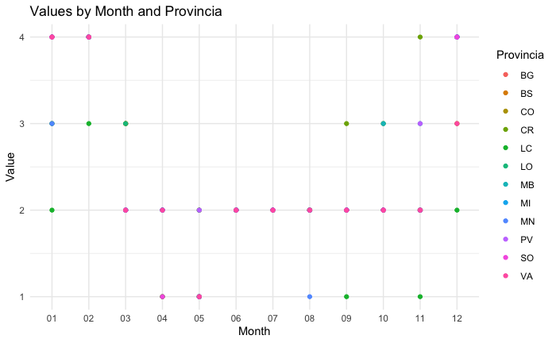

```r
data_long <- gather(pivot_data, key = "Month", value = "Value", -Provincia)

# Plot
ggplot(data_long, aes(x = Month, y = Value, group = Provincia, color = Provincia)) +
  #geom_line() +
  geom_point() +
  labs(title = "Values by Month and Provincia",
       x = "Month",
       y = "Value",
       color = "Provincia") +
  theme_minimal()
```